# hw05

Farnaz Sahragard

```r
library(tidyverse)
library(gapminder)
library(DT)
library(forcats)
library(here)
library(gridExtra)
library(cowplot)
```

## Exercise 1: Value of `here::here`

`here()` makes it easier for collaborators to share their projects with one another. Instead of using a path in the creator’s computer, `here()` detects the root directory and works with paths inside it on everyone’s computer, so we can download someone else’s project anywhere in our computer, and easily open any file in the project using `here()`. We don’t need to edit any path when we are trying to open a file. Moving a file doesn’t require the change of relative directory because `here` works directly from the root.`Here()` also makes it possible to open a `.R` file outside an Rstudio project. If there is another working directory inside a project, `here()` won’t be confused as it recognizes project directory first.

## Exercise 2: Factor management (gapminder)

1. Drop Oceania.
1. I used `continent` and `country` as variables. As required, I need to ensure that they are factors:

```r
class(gapminder$continent)
```

```
## [1] "factor"
```

```r
class(gapminder$country)
```

```
## [1] "factor"
```

They are factors.

2. Now I will `filter` the gapminder dataset: remove observations associated with the `continent` of Oceania.
- Before filtering:

```r
nlevels(gapminder$continent)
```

```
## [1] 5
```

```r
levels(gapminder$continent)
```

```
## [1] "Africa"   "Americas" "Asia"     "Europe"   "Oceania"
```

```r
nrow(gapminder)
```

```
## [1] 1704
```

There are 5 levels in `continent` and 1704 rows.

- After filtering:

```r
# create new dataset
gap_filtered_oceania <- gapminder %>%
              filter(continent != "Oceania")
# count levels and rows
nlevels(gap_filtered_oceania$continent)
```

```
## [1] 5
```

```r
levels(gap_filtered_oceania$continent)
```

```
## [1] "Africa"   "Americas" "Asia"     "Europe"   "Oceania"
```

```r
nrow(gap_filtered_oceania)
```

```
## [1] 1680
```

There are still 5 levels in `continent` but 1680 rows. This means we did filter some data but the factor “Oceania” still exists.

3. Now I am going to remove Oceania as an unused factor level.

```r
# create new dataset
gap_dropped_oceania <- gap_filtered_oceania %>%
              droplevels()
# count levels and rows
nlevels(gap_dropped_oceania$continent)
```

```
## [1] 4
```

```r
levels(gap_dropped_oceania$continent)
```

```
## [1] "Africa"   "Americas" "Asia"     "Europe"
```

```r
nrow(gap_dropped_oceania)
```

```
## [1] 1680
```

There are only 4 levels in `continent` and 1680 rows. It means we successfully removed some data and the factor **“Oceania”**.

2. Reorder the levels of `country`.

In this task, I am going to use the factor `country`. I want to see how GDP (`gdpPercap`*`pop` in `gapminder`) changes over time in the top 5 countries that have the highest GDP in 2019, according to [GDP Ranked by Country 2019](http://worldpopulationreview.com/countries/countries-by-gdp/). In the following steps, I will compare: - original data, - data after`arrange()`, - data with releveled factors. 1) Original dataset `gapGDP`.

```r
# choose 5 countries
top5gdp <- c("United States", "China", "Japan", "Germany", "India")
# modify gapminder
gapGDP <- gapminder %>%
  mutate(GDP = gdpPercap*pop/1000000000) %>% # create GDP column
  select(country, GDP, year) %>% # choose variables
  filter(country %in% top5gdp) %>%
  mutate_if(is.numeric, round) # round the digits of GDP
```

- The tibble:

```r
gapGDP %>%
  DT::datatable()
```

|  | country | GDP | year |
| --- | --- | --- | --- |
| 1 | China | 223 | 1952 |
| 2 | China | 367 | 1957 |
| 3 | China | 325 | 1962 |
| 4 | China | 462 | 1967 |
| 5 | China | 584 | 1972 |
| 6 | China | 699 | 1977 |
| 7 | China | 963 | 1982 |
| 8 | China | 1495 | 1987 |
| 9 | China | 1929 | 1992 |
| 10 | China | 2816 | 1997 |

[output cut: 50 more lines]

- The plot:

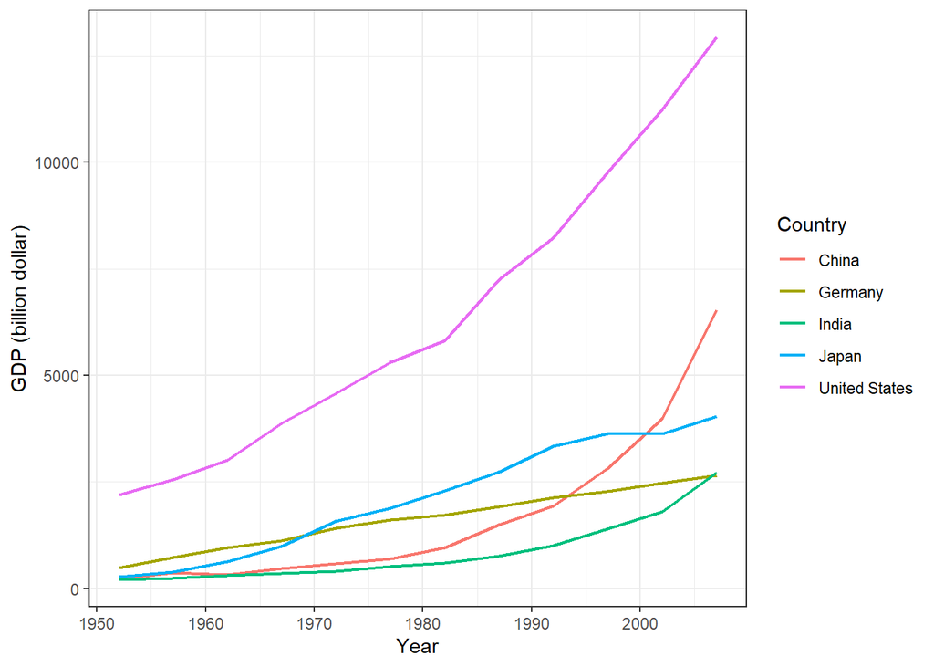

```r
ggplot(gapGDP, aes(x = year, y = GDP, # plot before re-leveling
                  color = country)) +
  geom_line(size = 0.8) +
  labs(x = "Year", y = "GDP (billion dollar)", color = "Country") +
  theme_bw()
```

In both **tibble** and **plot**, countries are listed alphabetically.

2)`gapGDP` after `arrange()`.

- The tibble:

```r
gapGDP_arranged <- gapGDP %>%
  group_by(country) %>%
  mutate(maxGDP = max(GDP)) %>%
  arrange(desc(maxGDP)) %>%
  select(-maxGDP)
  DT::datatable(gapGDP_arranged)
```

|  | country | GDP | year |
| --- | --- | --- | --- |
| 1 | United States | 2204 | 1952 |
| 2 | United States | 2553 | 1957 |
| 3 | United States | 3017 | 1962 |
| 4 | United States | 3881 | 1967 |
| 5 | United States | 4577 | 1972 |
| 6 | United States | 5302 | 1977 |
| 7 | United States | 5807 | 1982 |
| 8 | United States | 7256 | 1987 |
| 9 | United States | 8222 | 1992 |
| 10 | United States | 9761 | 1997 |

[output cut: 50 more lines]

- The plot:

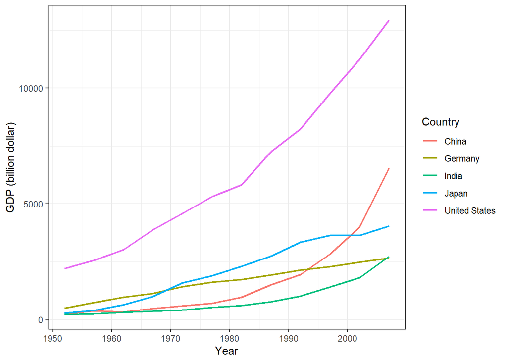

```r
ggplot(gapGDP_arranged,aes(x = year, y = GDP, # plot after arrange()
                  color = country) ) +
  geom_line(size = 0.8) +
  labs(x = "Year", y = "GDP (billion dollar)", color = "Country") +
  theme_bw()
```

It is clear that in **tibble**, countries are arranged in a descending order of their maximum GDP (I chose this as the statistical summary). However, in **plot**, countries are not ordered, which indicates that `arrange()` can’t relevel factors.

3. Re-level factors:

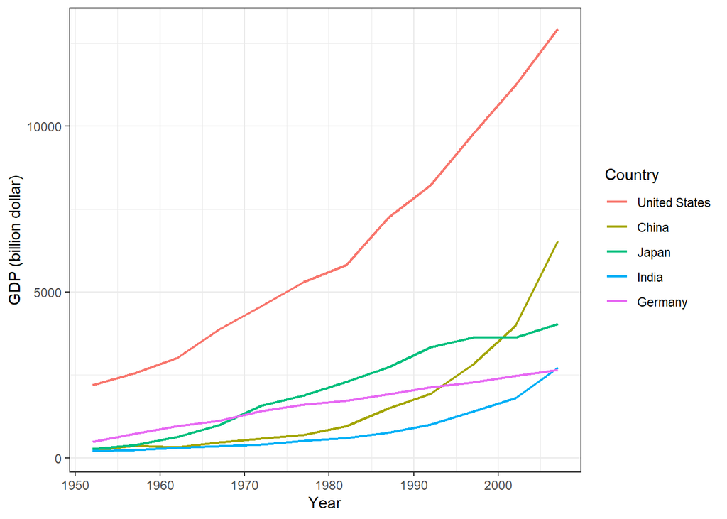

```r
ggplot(gapGDP, aes(x = year, y = GDP, # plot after relevling
                  color = fct_reorder2(country, year, GDP, max))) +
                        # fct_reorder2 is used for 2 variables
  geom_line(size = 0.8) +
  labs(x = "Year", y = "GDP (billion dollar)", color = "Country") +
  theme_bw()
```

After releveling factors, countries are ordered according to their maximum GDP in **plot**.

## Exercise 3: File input/output (I/O)

1. Create something new.

In this task, I want to see if life expectancies of each continent in the most recent year (2007) varied. I checked maximum values at first, but there isn’t much difference. So I tried minimum values.

```r
gaplifeExp_con <- gapminder %>%
                  filter(year == "2007") %>%
                  group_by(continent) %>%
                  summarise(lifeExpmin = min(lifeExp))
DT::datatable(gaplifeExp_con)
```

|  | continent | lifeExpmin |
| --- | --- | --- |
| 1 | Africa | 39.613 |
| 2 | Americas | 60.916 |
| 3 | Asia | 43.828 |
| 4 | Europe | 71.777 |
| 5 | Oceania | 80.204 |

2. Export dataset to disk, and reload it back.
- Export:

```r
write_csv(gaplifeExp_con, here::here("hw05","gaplifeExp_con.csv"))
```

- Reload:

```r
gaplifeExp_con_re <- read_csv(here::here("hw05", "gaplifeExp_con.csv"),
                              col_names = TRUE,
                              cols(continent = col_factor()))
                              # To make sure `continent` is a factor
DT::datatable(gaplifeExp_con_re)
```

|  | continent | lifeExpmin |
| --- | --- | --- |
| 1 | Africa | 39.613 |
| 2 | Americas | 60.916 |
| 3 | Asia | 43.828 |
| 4 | Europe | 71.777 |
| 5 | Oceania | 80.204 |

3. Re-level factors
- Before re-leveling factors:

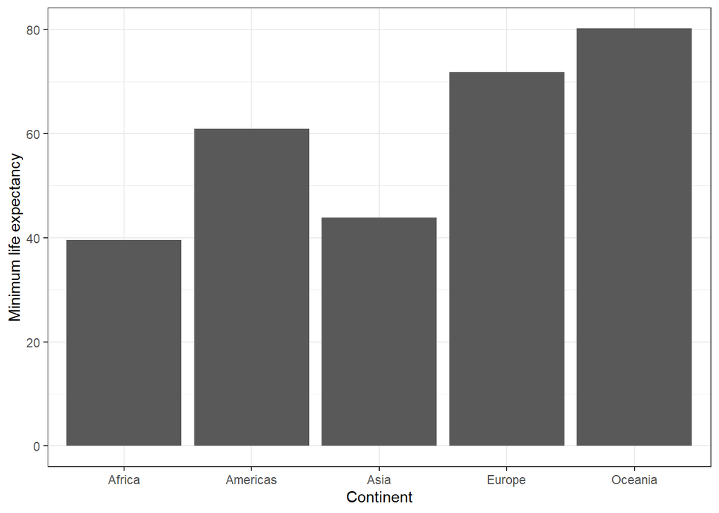

```r
gaplifeExp_con_re %>%
  ggplot() +
  geom_col(aes(x = continent, y = lifeExpmin)) +
  theme_bw() +
  labs(x = "Continent", y = "Minimum life expectancy")
```

The continents are ordered alphabetically.

- After re-leveling factors:

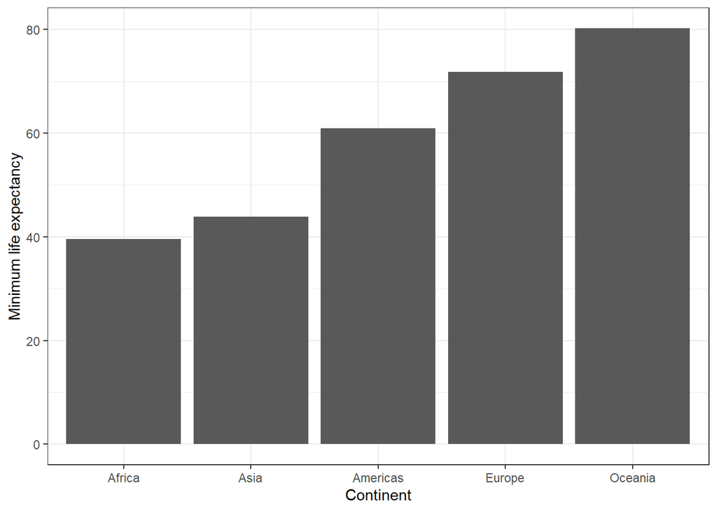

```r
gaplifeExp_con_re %>%
  ggplot() +
  geom_col(aes(x = fct_reorder(continent, lifeExpmin), y = lifeExpmin)) +
  theme_bw() +
  labs(x = "Continent", y = "Minimum life expectancy")
```

The continents are plotted in an ascending order of minimum life expectancy. It is clear that there indeed were differences. The lowest life expectancy took place in Africa (< 40 years old), and the highest existed in Oceania (> 80 years old).

## Exercise 4: Visualization design

I picked 2 plots from hw03 to modify.

1. Changes of life expectancy over time in different continents

```r
hw03_old <- gapminder %>% # old plot
  group_by(continent, year) %>%
  summarize(min = min(lifeExp),
            mean = mean(lifeExp),
            max = max(lifeExp)) %>%
  ggplot(aes(year, mean, colour = continent)) +
  geom_line()+
  geom_point()+
  scale_x_continuous("Year")+
  scale_y_continuous("Mean of life expectancy")+
  theme_light()+
  scale_color_brewer(palette="Paired", name = "Continent")
hw03_new <- gapminder %>% # new plot
  group_by(continent, year) %>%
  summarise(meanlifeExp = mean(lifeExp)) %>%
ggplot(aes(year, meanlifeExp,
                  color = fct_reorder2(continent, year, meanlifeExp))) +
  geom_line(size = 0.6) +
  labs(x = "Year", y = "Mean of life expectancy", color = "Continent") +
  theme_classic()
```

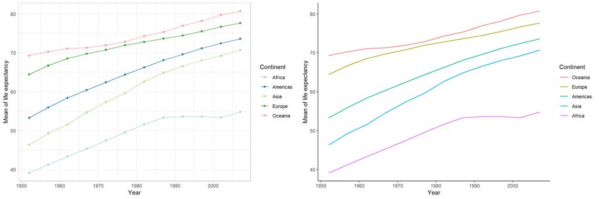

```r
cowplot::plot_grid(hw03_old, hw03_new, ncol = 2, nrow = 1)
```

Changes of life expectancy over time in different continents, old(left) and new (right)

| What I changed | Oldl | New |
| --- | --- | --- |
| Factor re-leveling | Orders of continents don’t match in lines and legend | Matched! |
| Color | Colors are not very easy to differentiate from each other | easier |
| Background | Grids in graph are kind of distractive | White, lines are easier to be seen |
| Points | Could be redundant if readers are only interested in general trends | Removed, trends are more clear |

2. Changes of GDP per capita in each continent over time. (From hw02)

```r
hw02_old <- ggplot(gapminder, aes(gdpPercap, color = continent)) +
  geom_line(stat = "density", size = 0.8) +
  scale_x_log10("GDP per capita", labels = scales::dollar_format())+
  scale_y_continuous("Density")+
  theme_light()+
  scale_color_brewer(palette="Set1", name = "Continent")
hw02_new <- ggplot(gapminder, aes(x = gdpPercap, y = fct_rev(continent)))+
  ggridges::geom_density_ridges()+
  theme_classic()+
  scale_x_continuous("GDP per capita", labels = scales::dollar_format())+
  scale_y_discrete("Continent")
```

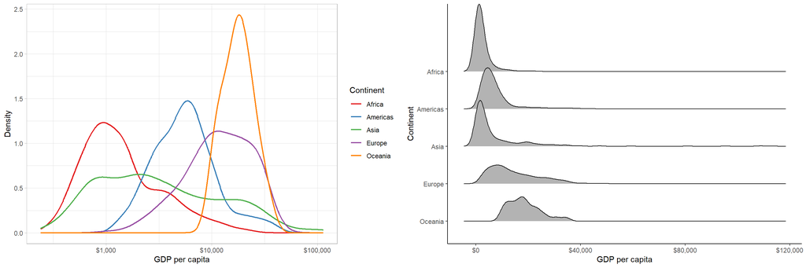

```r
cowplot::plot_grid(hw02_old, hw02_new, ncol = 2, nrow = 1)
```

GDP per capita distribution in different continents, old(left) and new (right)

| What I changed | Old | New |
| --- | --- | --- |
| Factor re-leveling | Continents are overlapped | Continents are placed alphabetically |
| Plot type | Continents are overlapped | Continents are separated and easy to be seen |
| Background | Grids in graph are kind of distractive | White, density plots are easier to be seen |
| Color | Multiple colors as `continent` is an aesthetic | Since `continent` becomes the y-axis there is no need for colors. Still works if printed in black-and-white |

## Exercise 5: Writing figures to file

I will save the new plot of Changes of life expectancy over time in different continents, although I don’t think I can save the right plot if I don’t specify the object by `plot =`. We will see what R will give us.

```r
ggsave(here::here("hw05","new_lifeExp_year_continent.png"),
       dpi = 250,
       width = 10,
       height = 5)
```

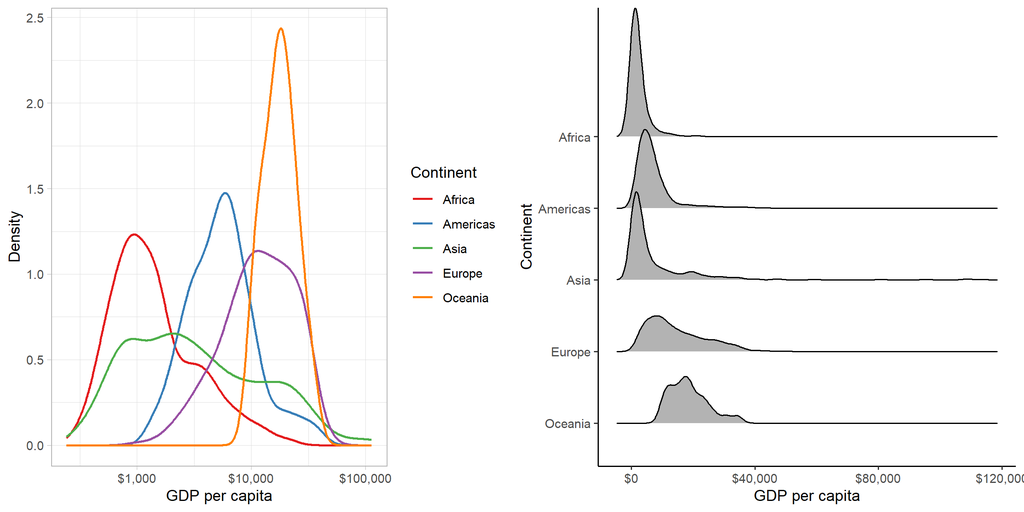

Fig.1 The plot we saved without specifying object

When I loaded the plot back, I found R saved the last plot we had created in the file. Now I will specify the plot object and try again.

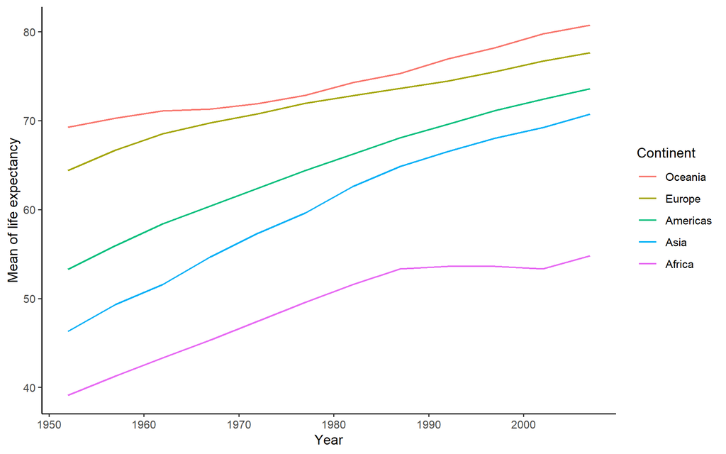

Fig.2 The plot we saved with specifying object

```r
ggsave(here::here("hw05","real_lifeExp_year_continent.png"),
       plot = hw03_new,
       dpi = 250,
       width = 8,
       height = 5)
```

This time, the plot I loadeded is correct, so it is important to specify which plot we would like to save.